# Analysis of Graduate School Admissions

Josh Leon - joshuarleon0123@gmail.com

2022-10-26

**I will be analyzing and modeling predictors for graduate school admission outcomes**

# **Outline**

- Loading and cleaning the data set
- Conducting exploratory analyses and producing informative figures
- Building and testing models
- Drawing conclusions about the data

## Data Set

A quick look at the data set:

```r
df %>% glimpse()
```

```
- Rows: 400
- Columns: 4
- $ admit <lgl> FALSE, TRUE, TRUE, TRUE, FALSE, TRUE, TRUE, FALSE, TRUE, FALSE, …
- $ gre   <dbl> 380, 660, 800, 640, 520, 760, 560, 400, 540, 700, 800, 440, 760,…
- $ gpa   <dbl> 3.61, 3.67, 4.00, 3.19, 2.93, 3.00, 2.98, 3.08, 3.39, 3.92, 4.00…
- $ rank  <dbl> 3, 3, 1, 4, 4, 2, 1, 2, 3, 2, 4, 1, 1, 2, 1, 3, 4, 3, 2, 1, 3, 2…
```

| Variable | Description |
| --- | --- |
| **admit** | A boolean value indicating whether the person was admitted |
| **gre** | The person’s Graduate Record Examinations (GRE) score |
| **gpa** | The person’s Grade Point Average (GPA) |
| **rank** | The rank of the person’s undergraduate institution with 1 being *Top Tier* |

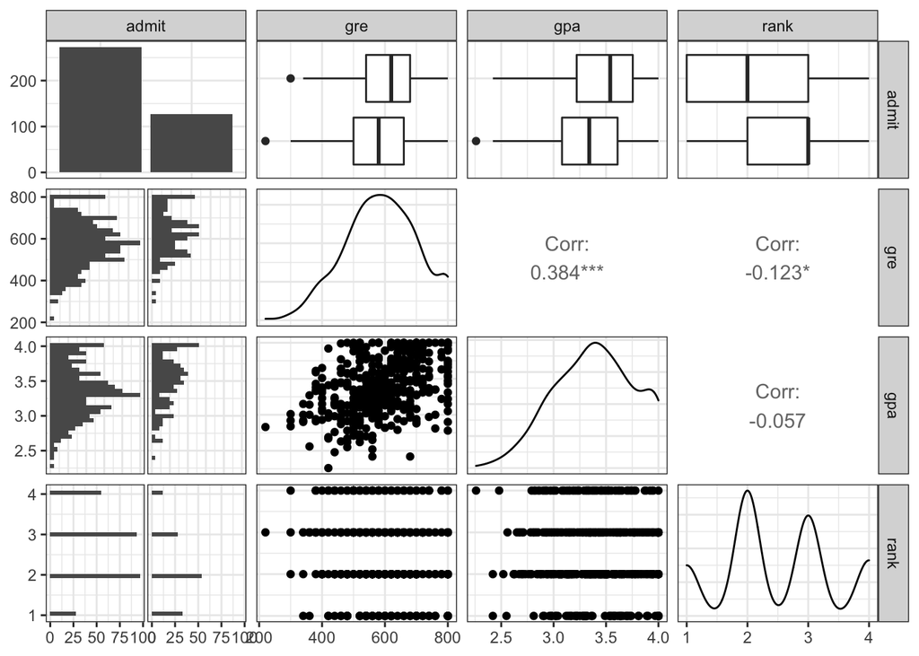

```r
df %>% GGally::ggpairs()
```

The goal is to determine the effect of the three predictors on admission result:

1. GRE score
2. GPA
3. Undergraduate institution rank

From the *ggpairs* plot, I can see that GRE scores are positively correlated with GPAs. Institution rank is negatively correlated with both GRE scores and GPAs.  
It’s difficult to determine if anything else is significant from the *ggpairs* plot. I’ll focus on a single plot at a time to display these relationships better.

## Exploring Relationships

### *Undergraduate Institution Rank*

The proportion of those accepted into graduate school decreases as the rank of their undergraduate institution decreases. People from top-tier schools get accepted 54% of the time while people from *bottom-tier* schools only get accepted 18% of the time.

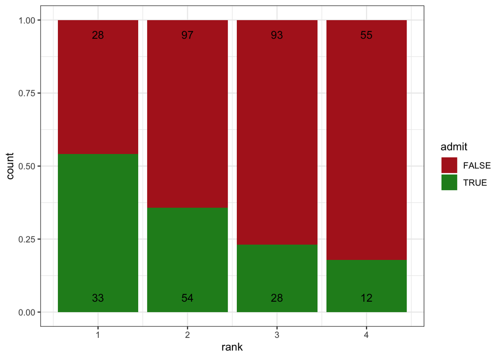

```r
df %>%
  ggplot(aes(x=rank, fill=admit)) +
  geom_bar(position="fill") +
  geom_text(data = df_count %>% filter(admit == 'TRUE'),
            aes(x = rank, y = 0.05, label = n)) +
  geom_text(data = df_count %>% filter(admit == 'FALSE'),
            aes(x = rank, y = 0.95, label = n)) +
  labs(y = 'count') +
  scale_fill_manual(values = c('firebrick', 'forestgreen'))
```

### *GPA and GRE*

The Black trend line represents the overall relationship between GRE score and GPA. It appears that those people with a low GPA AND a low GRE score are more likely to not be accepted into graduate school. For rank 1 and 4 schools, there doesn’t appear to be a correlation between GPA and GRE score for students who were accepted into a graduate school. For all ranks, the trend line for those who weren’t accepted into a graduate school closely follows the overall correlation between GPA and GRE scores.

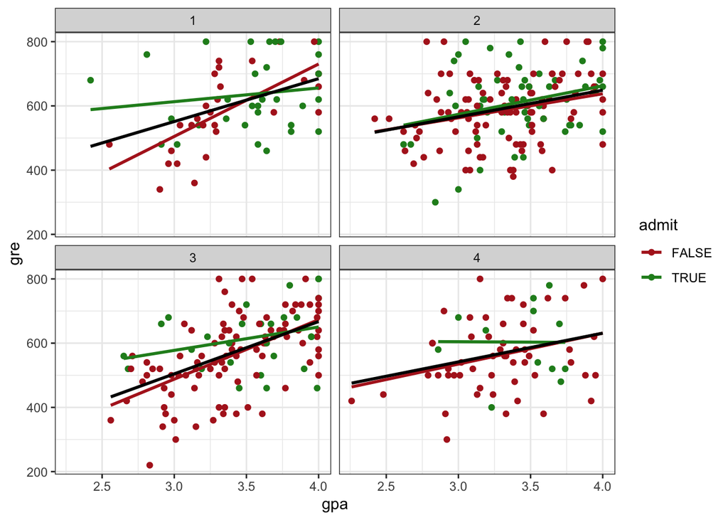

```r
df %>%
  ggplot(aes(x = gpa, y = gre, color = admit)) +
  geom_point() +
  geom_smooth(method = "glm", se = FALSE) +
  geom_smooth(aes(x = gpa, y = gre), color = 'black', method = "glm", se = FALSE) +
  scale_color_manual(values = c('firebrick', 'forestgreen')) +
  facet_wrap(~rank)
```

**When looking at just the GPA numbers, a slight difference can be seen in the average for those accepted (3.49) and those not accepted (3.34).**

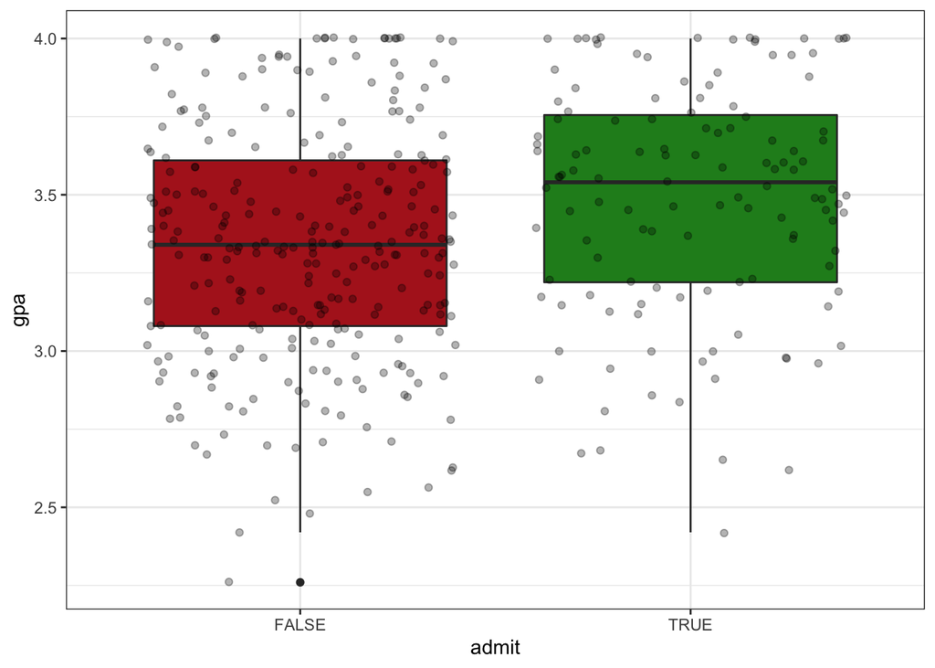

**A difference in the average GRE scores (46) can be seen between those accepted and those not accepted**

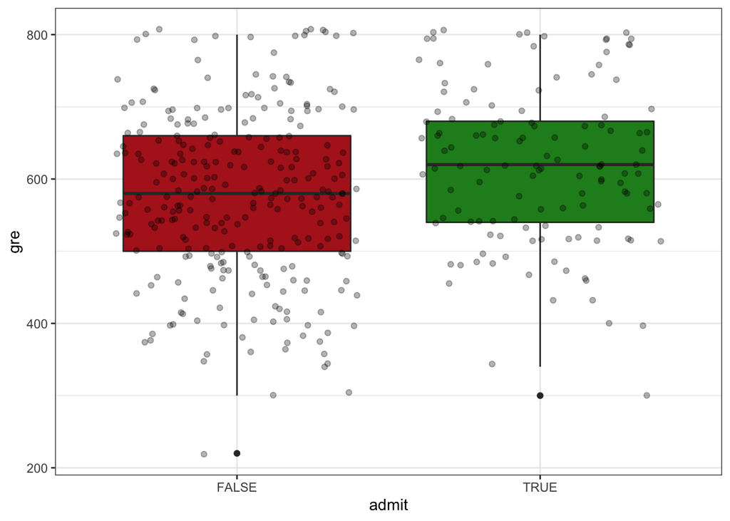

After looking at the plots, the rank of the undergraduate institution appears to be the most influential factor. I’ll make a few models next to see if this claim is supported.

## Model testing

```r
mod1 <-
  glm(data = df,
      formula = admit ~ rank,
      family = 'binomial')

mod2 <-
  glm(data = df,
      formula = admit ~ rank * gpa,
      family = 'binomial')

mod3 <-
  glm(data = df,
      formula = admit ~ rank * gre,
      family = 'binomial')

mod4 <-
  glm(data = df,
      formula = admit ~ gpa * gre,
      family = 'binomial')
mod5 <-
  glm(data = df,
      formula = admit ~ rank * gpa * gre,
      family = 'binomial')
```

**Comparing these models show that mod2 and mod5 perform the best**

| Name | Model | R2_Tjur | RMSE | Sigma | Log_loss | Score_log | Score_spherical | PCP | AIC_wt | BIC_wt | Performance_Score |
| --- | --- | --- | --- | --- | --- | --- | --- | --- | --- | --- | --- |
| mod2 | glm | 0.0899951 | 0.4438030 | 1.082272 | 0.5798001 | -50.18561 | 0.0032631 | 0.6056153 | 0.4271995 | 0.3899710 | 0.6020448 |
| mod5 | glm | 0.1061691 | 0.4396607 | 1.078843 | 0.5703124 | -50.59321 | 0.0048224 | 0.6126249 | 0.3480439 | 0.0001084 | 0.5594283 |
| mod1 | glm | 0.0604922 | 0.4509593 | 1.093277 | 0.5946391 | -49.03244 | 0.0103410 | 0.5928290 | 0.0083447 | 0.4123680 | 0.4928526 |
| mod3 | glm | 0.0851765 | 0.4451414 | 1.083862 | 0.5815047 | -49.96360 | 0.0042156 | 0.6035269 | 0.2160241 | 0.1971986 | 0.4896101 |
| mod4 | glm | 0.0522041 | 0.4529068 | 1.098494 | 0.5973113 | -48.63322 | 0.0044885 | 0.5892371 | 0.0003878 | 0.0003540 | 0.2415248 |

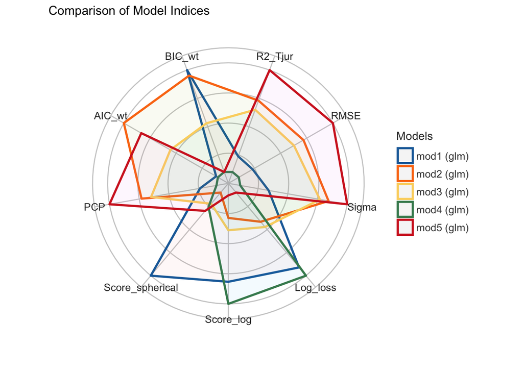

The comparison plot is messy so I’ll remove the bottom three preforming models `(mod1, mod3, and mod4)`. However, I’d still like to add a model built by the `stepAIC` function from the `MASS` library to the comparison.

```r
step <- MASS::stepAIC(mod5, trace = 0)
mod6 <-
  glm(data = df,
      formula = step$formula,
      family = 'binomial')
```

The formula for the new step model is `admit ~ rank + gpa + gre + gpa:gre`

Comparing these three models shows that `mod6` is probably the best preforming model. However, I’ll use both `mod6` and `mod5` to make predictions.

```r
final_comparison <- compare_performance(mod2, mod5, mod6, rank = TRUE)
final_comparison %>%
  kable() %>%
  kable_minimal()
```

| Name | Model | R2_Tjur | RMSE | Sigma | Log_loss | Score_log | Score_spherical | PCP | AIC_wt | BIC_wt | Performance_Score |
| --- | --- | --- | --- | --- | --- | --- | --- | --- | --- | --- | --- |
| mod6 | glm | 0.1048746 | 0.4399238 | 1.075148 | 0.5707469 | -50.48147 | 0.0040620 | 0.6120639 | 0.8834338 | 0.6514168 | 0.7342976 |
| mod5 | glm | 0.1061691 | 0.4396607 | 1.078843 | 0.5703124 | -50.59321 | 0.0048224 | 0.6126249 | 0.0523322 | 0.0000969 | 0.4979228 |
| mod2 | glm | 0.0899951 | 0.4438030 | 1.082272 | 0.5798001 | -50.18561 | 0.0032631 | 0.6056153 | 0.0642341 | 0.3484863 | 0.2832465 |

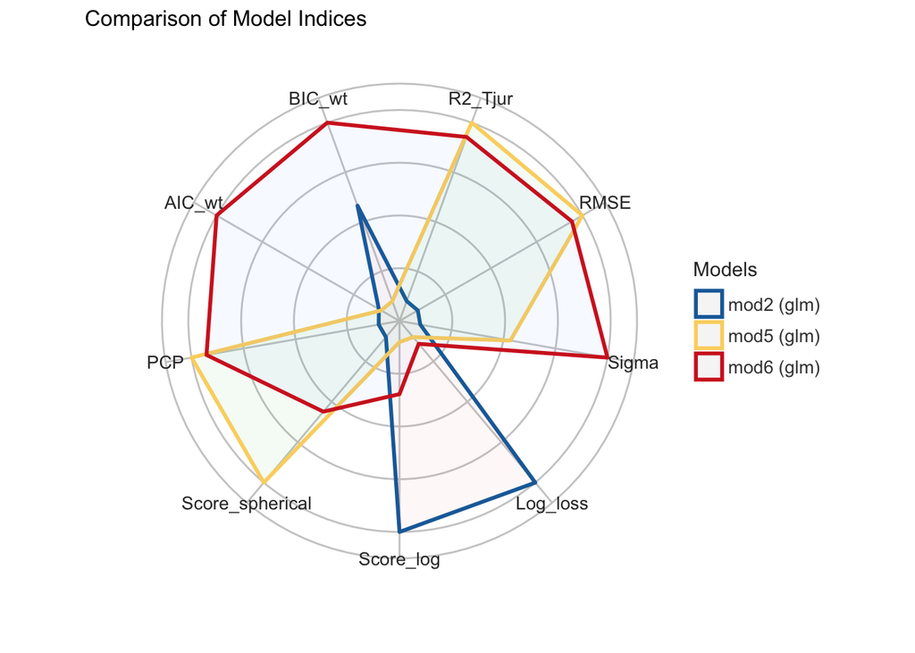

## Model Predictions

Graphing the models against the predictions doesn’t seem to show much difference. I’ll create fake data to test my models next.

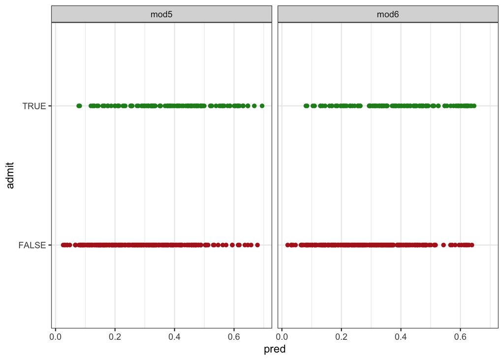

```r
df %>%
  gather_predictions(mod5, mod6, type = 'response') %>%
  ggplot(aes(x = pred, y = admit, color = admit)) +
  geom_point(show.legend = FALSE,) +
  facet_wrap(~model) +
  scale_color_manual(values = c('firebrick', 'forestgreen'))
```

#### *Acceptance prediction differences between low performing and high performing students*

To start, I’ll make predictions by creating fake data that compares a person with low GRE scores AND a low GPA to a person with high GRE scores AND a high GPA from each undergraduate institution rank level. I’ll be using the 1st quartile and the 3rd quartile numbers from each rank to represent the *Low* and the *High* scores.

| Person | rank | rating | gre | gpa |
| --- | --- | --- | --- | --- |
| 1 | 1 | Low | 540 | 3.20 |
| 2 | 1 | High | 700 | 3.73 |
| 3 | 2 | Low | 520 | 3.10 |
| 4 | 2 | High | 660 | 3.62 |
| 5 | 3 | Low | 500 | 3.15 |
| 6 | 3 | High | 660 | 3.76 |
| 7 | 4 | Low | 500 | 3.08 |
| 8 | 4 | High | 660 | 3.54 |

The predictions made using `mod6` show that a person coming from a rank **1** undergraduate institution who has a **high** gpa AND a **high** gre score has the best chance of being accepted into a graduate school at 60.24% (Person #2). As expected, a person coming from a rank **4** undergraduate institution who has a **low** gpa AND a **low** gre score has the worst chance of being accepted into graduate school at 9.42% (Person #7).

| Person | Prediction |
| --- | --- |
| 1 | 43.01 |
| 2 | 60.24 |
| 3 | 26.29 |
| 4 | 44.10 |
| 5 | 16.69 |
| 6 | 32.51 |
| 7 | 9.42 |
| 8 | 19.62 |

**The predictions from `mod5` are very similar to those of `mod6`**

| Person | Prediction |
| --- | --- |
| 1 | 42.21 |
| 2 | 61.00 |
| 3 | 26.09 |
| 4 | 44.29 |
| 5 | 16.99 |
| 6 | 31.76 |
| 7 | 10.06 |
| 8 | 19.63 |

To reduce redundancy, I’ll just be using `mod6` for the remainder of this analysis.

An increase in the chance of being accepted to a graduate school can be seen as both GPA and GRE increase. The prediction increases as school rank increases.

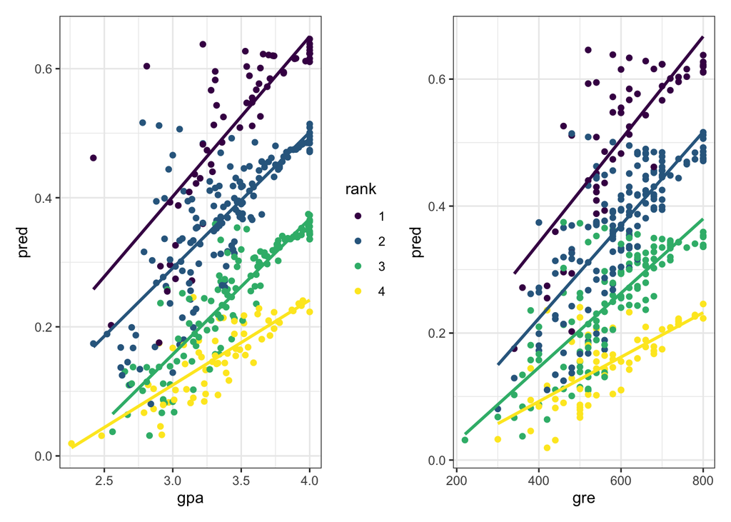

#### *Acceptance predictions based on either just GRE score or just GPA*

Now, I’ll alter the fake data so that GPAs are consistent while GRE scores are either low, average, or high. I’ll also make a data set that is the opposite, GRE scores are consistent while GPAs are either low, average or high. I’ll be using the overall mean from the data set for the *consistent values* and I will use the minimum, mean, and maximum numbers from each rank to represent the *Low*, *Average*, and the *High* scores.

The mean GPA used for all students in this fake data set is **3.39**

| Person | rank | rating | gre |
| --- | --- | --- | --- |
| 1 | 1 | Low GRE score | 340 |
| 2 | 1 | Average GRE score | 612 |
| 3 | 1 | High GRE score | 800 |
| 4 | 2 | Low GRE score | 300 |
| 5 | 2 | Average GRE score | 596 |
| 6 | 2 | High GRE score | 800 |
| 7 | 3 | Low GRE score | 220 |
| 8 | 3 | Average GRE score | 575 |
| 9 | 3 | High GRE score | 800 |
| 10 | 4 | Low GRE score | 300 |
| 11 | 4 | Average GRE score | 570 |
| 12 | 4 | High GRE score | 800 |

When GPAs are all the same, the predictions made show that the person coming from a rank **1** undergraduate institution who had a **high** GRE score has the best chance of being accepted into a graduate school at 63.19% (Person #3). As expected, the person coming from a rank **4** undergraduate institution who had a **low** GRE score has the worst chance of being accepted into graduate school at 8.79% (Person #10).

| Person | Prediction |
| --- | --- |
| 1 | 36.65 |
| 2 | 52.40 |
| 3 | 63.19 |
| 4 | 23.01 |
| 5 | 37.58 |
| 6 | 49.37 |
| 7 | 12.32 |
| 8 | 24.55 |
| 9 | 35.64 |
| 10 | 8.79 |
| 11 | 15.44 |
| 12 | 23.93 |

It is important to note that Person #9 and #12 both had high GRE scores but have a predicted value less than person #1 who had a low GRE score. Person #9 is from a rank **3** undergraduate institution and person #12 is from a rank **4** while person #1 is from a rank **1** institution. This indicates that the rank of the person’s undergraduate institution is an important predictor in acceptance to graduate schools.

**GRE scores appear to be less important as a predictor as the rank of the institution decreases**

The prediction difference between people who scored high and people who scored low on the GRE by Undergraduate ranking

| Rank | Prediction difference |
| --- | --- |
| 1 | 26.54 |
| 2 | 26.36 |
| 3 | 23.32 |
| 4 | 15.14 |

Now looking at the predictions when GPAs are different and the GRE scores are consistent.

The mean GRE score used for all students in this fake data set is **588**

| Person | rank | rating | gpa |
| --- | --- | --- | --- |
| 1 | 1 | Low GPA | 2.42 |
| 2 | 1 | Average GPA | 3.45 |
| 3 | 1 | High GPA | 4.00 |
| 4 | 2 | Low GPA | 2.42 |
| 5 | 2 | Average GPA | 3.36 |
| 6 | 2 | High GPA | 4.00 |
| 7 | 3 | Low GPA | 2.56 |
| 8 | 3 | Average GPA | 3.43 |
| 9 | 3 | High GPA | 4.00 |
| 10 | 4 | Low GPA | 2.26 |
| 11 | 4 | Average GPA | 3.32 |
| 12 | 4 | High GPA | 4.00 |

The results are very similar to the table above. The rank of the undergraduate institution appears to be the most influential predictor.

| Person | Prediction |
| --- | --- |
| 1 | 31.09 |
| 2 | 52.27 |
| 3 | 63.75 |
| 4 | 20.40 |
| 5 | 36.53 |
| 6 | 49.97 |
| 7 | 14.10 |
| 8 | 25.77 |
| 9 | 36.19 |
| 10 | 6.72 |
| 11 | 15.21 |
| 12 | 24.36 |

Looking at the prediction difference between the two analyses above.

A positive number indicates that the consistent GPA prediction is higher than the consistent GRE prediction

| Person | Rank | Prediction_consistent_GPA | Prediction_consistent_GRE | Difference |
| --- | --- | --- | --- | --- |
| 1 | 1 | 36.65 | 31.09 | 5.56 |
| 2 | 1 | 52.40 | 52.27 | 0.13 |
| 3 | 1 | 63.19 | 63.75 | -0.56 |
| 4 | 2 | 23.01 | 20.40 | 2.61 |
| 5 | 2 | 37.58 | 36.53 | 1.05 |
| 6 | 2 | 49.37 | 49.97 | -0.60 |
| 7 | 3 | 12.32 | 14.10 | -1.78 |
| 8 | 3 | 24.55 | 25.77 | -1.22 |
| 9 | 3 | 35.64 | 36.19 | -0.55 |
| 10 | 4 | 8.79 | 6.72 | 2.07 |
| 11 | 4 | 15.44 | 15.21 | 0.23 |
| 12 | 4 | 23.93 | 24.36 | -0.43 |

A t-test of these two predictions show no significant difference (p = 0.9387)

```r
t.test(Prediction_consistent_GPA, y = Prediction_consistent_GRE)
```

## Conclusions

1. The rank of the undergraduate institution has the largest influence on whether a student will be accepted into a graduate school
2. The influence of GRE scores and GPA are more influential in top-tier schools
3. No significant differences were found when determining if GPA or GRE scores were more influential
4. The discrete logistic models created here weren’t very good at predicting student acceptance to graduate schools.